# exFINDER suggests critical external signals and targets during sensory neurogenesis in mouse.

Changhan He

02 三月, 2023

This vignette outlines the steps of applying exFINDER to mouse single-cell transcriptomics data on: (1) identifying external signals associated to the differentiation during sensory neurogenesis in mouse; (2) inferring and analyzing the external signal-target signaling network (exSigNet); (3) critical external signals and targets; (4) clustering the signaling networks between every ligand-target pair; (5) evaluate the GO analysis outputs.

## Load the required libraries

```r
library(exFINDER)
library(Seurat)
library(ggplot2)
library(patchwork)
library(RColorBrewer)
library(dplyr)
library(pheatmap)
library(ggraph)
```

# Part I: Data input & processing & visualizing

The mouse dataset (pagoda2 object) can be downloaded from: https://figshare.com/s/5356bda5f673c68cc7b3) and can be visualized by running the following chunck:

```r
# library(pagoda2)
# p2w <- readRDS("/Users/chang/Documents/exFINDER/testdata/Faure2020_Mouse_GSE150150_p2w_sensory.rds")
# p2 <- p2w$originalP2object
# p2$plotEmbedding(type='PCA', show.legend=T, mark.clusters=T, min.group.size=1)
```

```r
# this Seurat object is converted from the pagoda2 object
# and can be downloaded from: https://figshare.com/s/45e0f717eb45a874ad3a
Mdata <- readRDS("/Users/chang/Documents/exFINDER/testdata/Faure2020_Mouse_GSE150150_p2w_sensory_Seurat.rds")
Mdata = UpdateSeuratObject(object = Mdata)
```

```
#> Validating object structure
#> Updating object slots
#> Ensuring keys are in the proper structure
#> Ensuring feature names don't have underscores or pipes
#> Object representation is consistent with the most current Seurat version
```

```r
Data1 <- Mdata
```

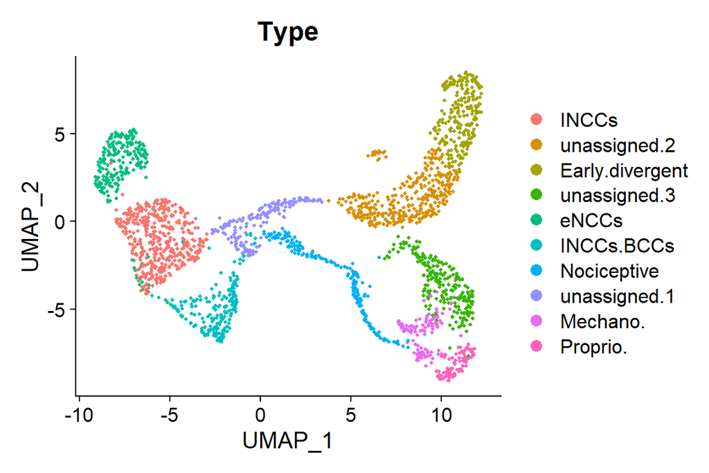

```r
# visualze the dataset
DimPlot(object = Data1, reduction = "umap", group.by = "Type", pt.size = 0.75)
```

```r
# if needed, users can discover and save marker genes of each cluster by running this chunk (optional)

# Type <- levels(Data1@meta.data$Type)
# n <- length(Type)
# Data1@active.ident <- Data1@meta.data$Type
# Data1.marker <- c()
#
# for (i in 1:n) {
#   cluster.markers <- FindMarkers(Data1,
#                                  ident.1 = Type[i] ,
#                                  group.by = "Type",
#                                  only.pos = TRUE,
#                                  min.pct = 0.25,
#                                  logfc.threshold = 0.25)
#
#   cluster.markers %>%
#     slice_max(order_by = -p_val)
#   cluster.markers <- cluster.markers[1:100,]
#
#   Data1.marker <- c(Data1.marker, rownames(cluster.markers[1:10, ]))
#
#   write.csv(x = cluster.markers , file = paste("../markers/Faure2020_Mouse_marker/Faure2020_Mouse_markers_",Type[i],".csv",sep=""))
# }
```

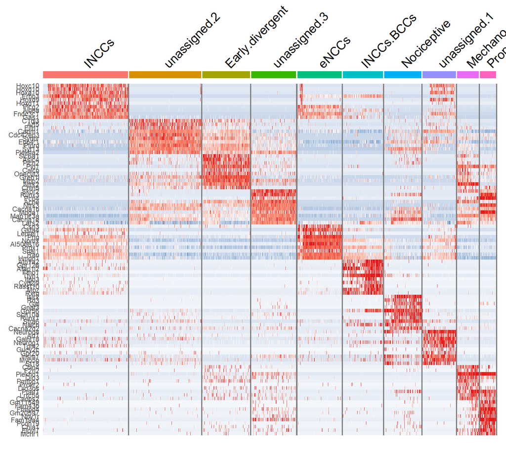

```r
# if all marker genes are saved, we can directly load and visualize
Type <- levels(Data1@meta.data$Type)
n <- length(Type)
Data1@active.ident <- Data1@meta.data$Type
Data1.marker <- c()

for (i in 1:n) {
  cluster.markers <- read.csv(file = paste("../markers/Faure2020_Mouse_marker/Faure2020_Mouse_markers_",Type[i],".csv",sep=""))

  cluster.markers <- cluster.markers$X[1:10]

  Data1.marker <- c(Data1.marker, cluster.markers)
}

DoHeatmap(Data1, features = Data1.marker) + NoLegend() +
  scale_fill_gradientn(colors = c("#377EB8", "white", "#E41A1C"))
```

# Part II: Load exFINDER database (and optional ligand-receptor database)

*exFINDER database* is available for human, mouse, and zebrafish. *ligand-receptor database* is used for inferring functionally related signaling pathways from the exSigNet, here we use the ligand-receptor database from CellChat.

```r
# load exFINDER database
load("../data/LR_layer1_mouse.rda")
load("../data/RTF_layer2_mouse.rda")
load("../data/TFT_layer3_mouse.rda")

exFINDER.M <- list()
exFINDER.M[[1]] <- LR_layer1_mouse
exFINDER.M[[2]] <- RTF_layer2_mouse
exFINDER.M[[3]] <- TFT_layer3_mouse
```

```r
# load CellChatDB
# load("../data/interaction_input_CellChatDB_human.rda")
load("../data/interaction_input_CellChatDB_mouse.rda")
# load("../data/interaction_input_CellChatDB_zebrafish.rda")
```

## Prepare the inputs for exFINDER analysis

```r
exp.data <- Data1@assays$RNA@data
meta.data <- Data1@meta.data
```

# Part III: Identify external signals that targeting Proprio. cells

To identify differentiation-associated external signals, we select the marker genes of Proprio. cells (one of the differentiated cell groups) as our target genes. However, the target genes *do not have to be* marker genes.

## Setup target genes and infer ltGRN

```r
marker <- read.csv(file = "../markers/Faure2020_Mouse_marker/Faure2020_Mouse_markers_Proprio..csv")
target.gene <- marker$X[1:10]

ltGRN <- get_ltGRN(Target = target.gene, DB = exFINDER.M)
```

## Setup the cutoff thresholds for “barely expressed genes” and “highly expressed genes” for NC cells

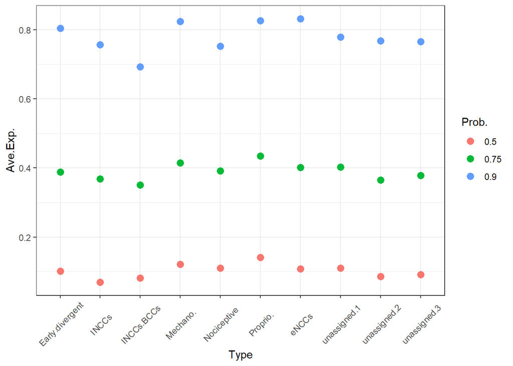

```r
# Check the average expression levels in each cell population group
percentile_data <- get_percentile(Exp.Data = exp.data,
               Meta.Data = meta.data,
               percentile = c(.5, .75, .90))

p <- ggplot(data=percentile_data, aes(x=Type, y=Ave.Exp., color=Prob.)) +
  geom_point(size=3) +
  theme_bw() +
    theme(axis.text.x = element_text(angle = 45, hjust = 0.5, vjust = 0.5))

p
```

```r
# ggsave(p, filename="Faure2020_Mouse_Part1_percentile.pdf")
```

## Identify external signals and infer exSigNet

```r
# infer potential external signals from ltGRN
Pex <- get_potentialex(Graph = ltGRN,
                Exp.Data = exp.data,
                Meta.Data = meta.data,
                cutoff = -0.1,
                AG.L = NULL)
head(Pex)
```

```
#> [1] "Dsg1b"   "Pcdhb16" "Fat2"    "Dsg1a"   "Cdh1"    "Lgals3"
```

```r
# infer exSigNet (R, TF, T are all highly expressed, L comes from the potential external signals)
exSigNet <- get_exSigNet(Graph = ltGRN,
                       Ligands = Pex,
                       Exp.Data = exp.data,
                       Meta.Data = meta.data,
                       par.cutoff = c(1, 1),
                       AG.R = c("Proprio.", "unassigned.3"),
                       AG.TF = c("Proprio."))
```

```
#> [1] "No overlap found!"
```

```r
# exSigNet
```

```r
# based on this "exSigNet", we identify the receptors that only activated by these external signals
exSigNet <- filterLR_exSigNet(Graph = exSigNet,
                  Exp.Data = exp.data,
                  DB = exFINDER.M)
```

```
#> [1] "No overlap found!"
```

```r
exSigNet
```

```
#> $Graph.Edge
#>       from      to   source           path from.Role  to.Role
#> 1   Slurp1  Chrna4 CellChat  Slurp1*Chrna4    Ligand Receptor
#> 2     Fpr3     App   IUPHAR       Fpr3*App    Ligand Receptor
#> 3     Fpr2     App   IUPHAR       Fpr2*App    Ligand Receptor
#> 4     Pld2    Arf1   IUPHAR      Pld2*Arf1    Ligand Receptor
#> 5   Slurp1  Chrnb2 CellChat  Slurp1*Chrnb2    Ligand Receptor
#> 6      App Smarcb1 NicheNet    App*Smarcb1  Receptor       TF
#> 7      App    Xbp1 NicheNet       App*Xbp1  Receptor       TF
#> 8      App   Rab3a NicheNet      App*Rab3a  Receptor       TF
#> 9      App    Kras NicheNet       App*Kras  Receptor       TF
#> 10     App  Ctnnb1 NicheNet     App*Ctnnb1  Receptor       TF
#> 11  Chrna4   Stat3 NicheNet   Chrna4*Stat3  Receptor       TF
#> 12     App   Stat3 NicheNet      App*Stat3  Receptor       TF
#> 13  Chrnb2   Stat3 NicheNet   Chrnb2*Stat3  Receptor       TF
```

[output cut: 46 more lines]

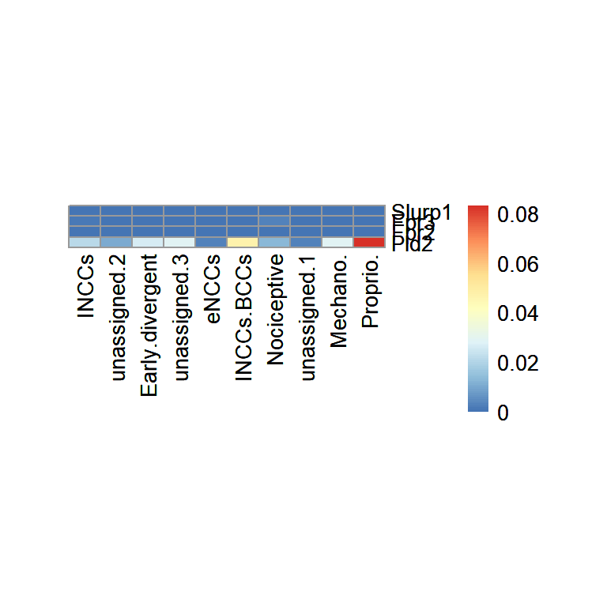

```r
# check the inferred external signals and their expressions via heatmap
exS <- exSigNet$Graph.Node$Gene[exSigNet$Graph.Node$Role == "Ligand"]

get_heatmap(Gene = exS,
          Exp.Data = exp.data,
          Meta.Data = meta.data)
```

```r
# calculate the expression levels
exSigNet <- get_NodeValue(Graph = exSigNet,
                          Exp.Data = exp.data,
                          Meta.Data = meta.data,
                          AG.R = c("Proprio.", "unassigned.3"),
                          AG.TF = c("Proprio."),
                          AG.T = c("Proprio."),
                          Exp.ExData = NULL,
                          Meta.ExData = NULL,
                          AG.ExData = NULL)

# predict signaling strengths
exSigNet <- get_EdgeWeight(Graph = exSigNet,
               Kh = 2)
```

### Visualize the exSigNet via heatmap plot

```r
# prepare the dataframe for heatmap plot
exS_exp <- get_AveExp(Gene = exSigNet$Graph.Node$Gene,
           Exp.Data = exp.data,
           Meta.Data = meta.data)

exS_exp.HP <- exS_exp
exS_exp.HP <- exS_exp.HP[, -1]
row.names(exS_exp.HP) <- exS_exp$Gene

## customize the row labels and col labels
annotation_row <- data.frame(Role = exSigNet$Graph.Node$Role)
row.names(annotation_row) <- row.names(exS_exp.HP)
```

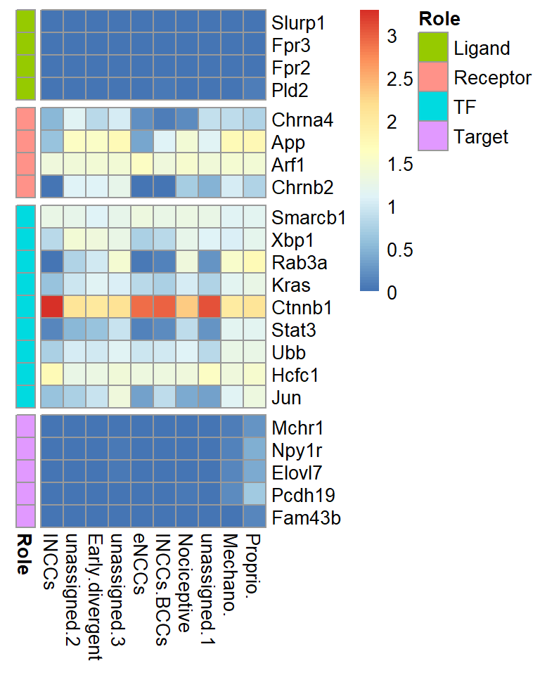

```r
# heatmap plot
pheatmap(exS_exp.HP,
         cluster_row = FALSE, cluster_cols = FALSE,
         cellwidth = 12, cellheight = 12,
         gaps_row = c(4, 8, 17),
         fontsize_row = 10,
         fontsize_col = 10,
         annotation_row = annotation_row)
```

### Visualize the exSigNet via hierarchy plot

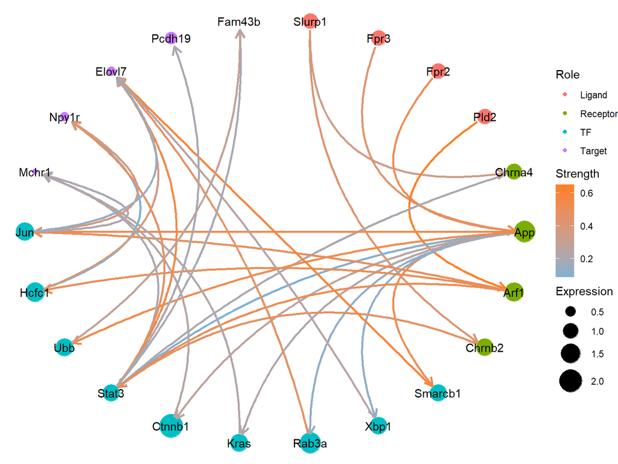

```r
# hierarchy plot
exSigNet_plot <- get_readyforplot(Graph = exSigNet)

ggraph(exSigNet_plot[[1]], layout = 'dendrogram', circular = TRUE) +
  geom_node_point(aes(filter = leaf, x=x, y=y, colour=Role, size=Expression)) +
  theme_void() +
  geom_conn_bundle(data = get_con(from = exSigNet_plot[[2]]$from,
                                  to = exSigNet_plot[[2]]$to,
                                  Strength = exSigNet_plot[[2]]$weight), width = 1.0, aes(colour=Strength),
                   arrow = arrow(length = unit(3, 'mm')), start_cap = circle(3, 'mm'), end_cap = circle(3, 'mm')) +
  scale_edge_color_continuous(low="#80b1d3", high="#FF7F24")+
  geom_node_text(aes(label = node)) +
  scale_size_continuous( range = c(0.1,10) )
```

### Visualize the exSigNet via hive plot

```r
library(dplyr)
library(igraph)
# prepare for hive plot
Graph <- exSigNet

Role <- factor(x = Graph$Graph.Node$Role, levels = c("Ligand", "Receptor", "TF", "Target"))
edges <- data.frame("from" = Graph$Graph.Edge$from, "to" = Graph$Graph.Edge$to)

edges <- edges %>%
  mutate(weight = Graph$Graph.Edge$Weight)

nodes <- data.frame(name = Graph$Graph.Node$Gene, role = Role, value = Graph$Graph.Node$Size)
g2 <- graph_from_data_frame(vertices = nodes, d = edges)
```

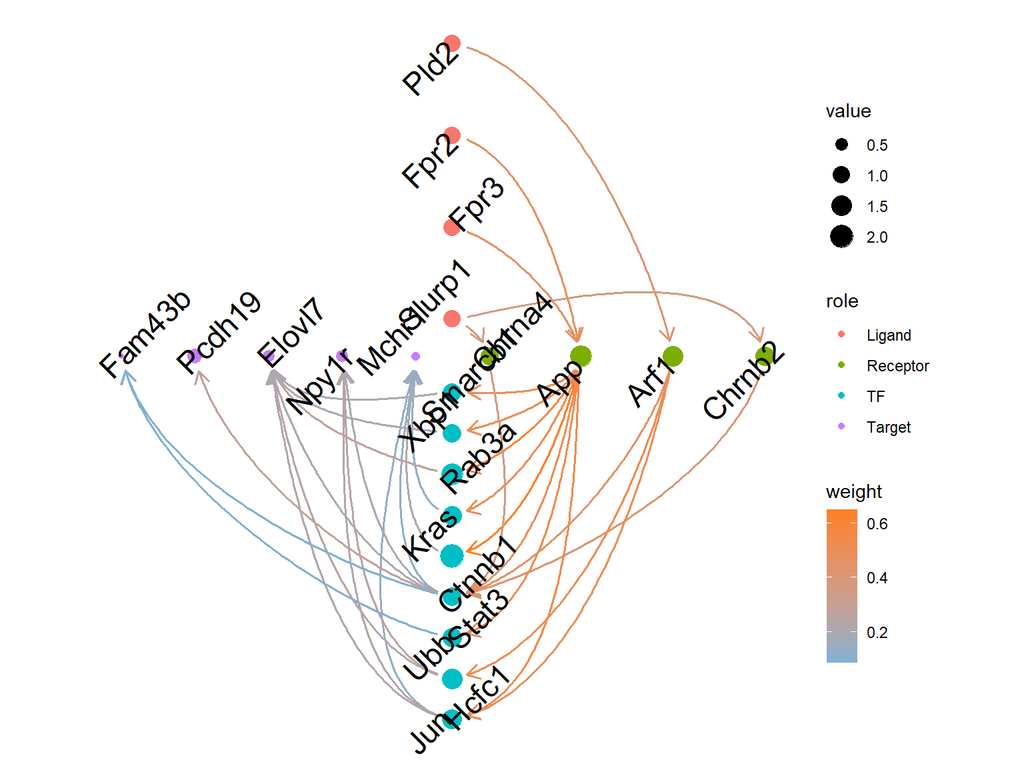

```r
ggraph(g2, 'hive', axis = nodes$role) +
  geom_edge_hive(aes(colour = weight), width = 0.7, arrow = arrow(length = unit(3, 'mm')), start_cap = circle(3, 'mm'), end_cap = circle(3, 'mm')) +
  # geom_axis_hive(aes(colour = role), size = 0, label = FALSE) +
  geom_node_point(aes(size = value, color = role),  alpha = 1) +
  geom_node_text(aes(label = name), angle = 45,  size = 6, repel = TRUE) +
  coord_fixed() +
  scale_edge_color_continuous(low="#80b1d3", high="#FF7F24") +
  theme_minimal() +
  theme(
    panel.grid = element_blank(),
    axis.line = element_blank(),
    axis.ticks =element_blank(),
    axis.text =element_blank(),
    axis.title = element_blank()
  )
```

# Part IV: Predict critical external signals and targets based on total signal flows

```r
# compute and compare the L-R maxflow
df <- get_LRMaxFlow(exSigNet)
df.TotalFlow <- compare_MaxFlow(df = df)
df.TotalFlow
```

```
#>     Gene TotalFlow   Role
#> 1   Fpr2 1.8161743 Ligand
#> 2   Fpr3 1.8161743 Ligand
#> 3   Pld2 1.4665124 Ligand
#> 4 Slurp1 0.8816907 Ligand
#> 5 Elovl7 1.5526094 Target
#> 6 Fam43b 0.5286566 Target
#> 7  Mchr1 1.3227529 Target
#> 8  Npy1r 1.4616412 Target
#> 9 Pcdh19 1.1148917 Target
```

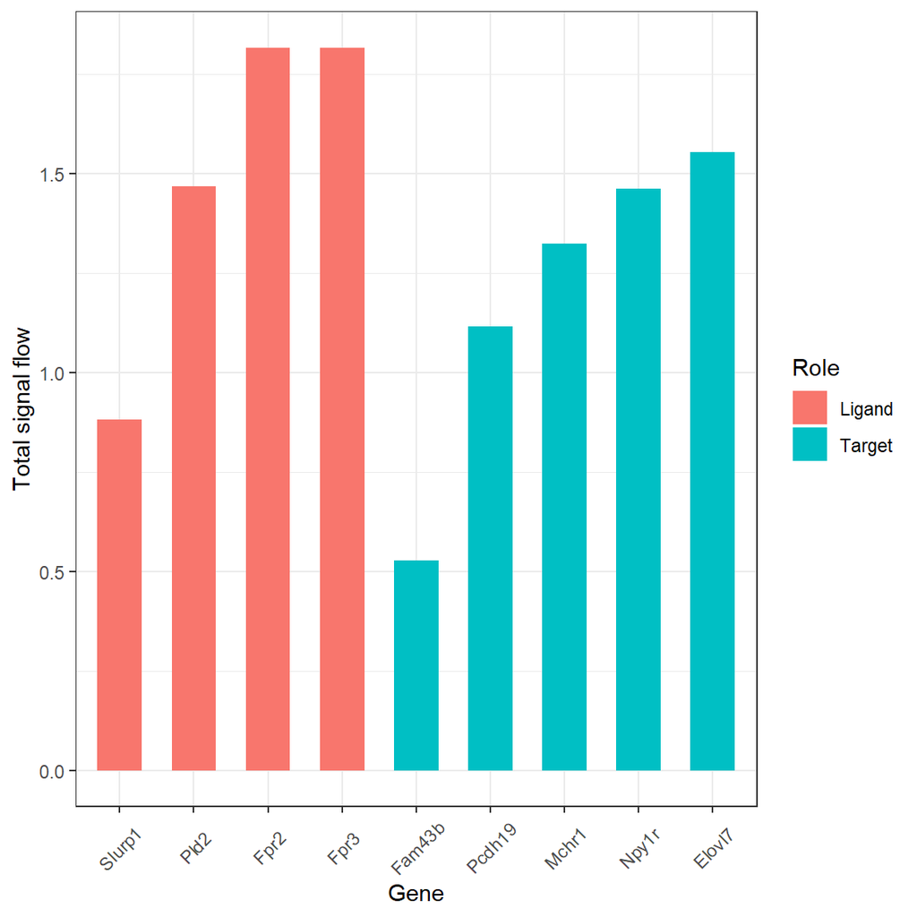

```r
library(forcats)
# bar plot of the signal comparing results
df.TotalFlow %>%
  mutate(Gene = fct_reorder(Gene, TotalFlow* (Role=='Ligand'))) %>%
  mutate(Gene = fct_reorder(Gene, TotalFlow* (Role=='Target'))) %>%
  # mutate(Gene = fct_reorder(Gene, SI* (Type=='Full network'))) %>%
  ggplot(aes(x=Gene, y=TotalFlow,  fill=Role)) +
    geom_bar(stat="identity", alpha=1, width=.6) +
    xlab("Gene") +
    ylab("Total signal flow") +
    theme_bw() +
    theme(axis.text.x = element_text(angle = 45, hjust = 0.5, vjust = 0.5))
```

# Part V: Clustering signaling networks between ligand-target pairs

```r
# calculate the matrix
df <- get_SimilarityMatrix(Graph = exSigNet)
```

```r
desc_stats = data.frame( Min=apply(df, 2, min),#minimum
                          Med=apply(df, 2, median),#median
                          Mean=apply(df, 2, mean),#mean
                          SD=apply(df, 2, sd),#Standard deviation
                          Max=apply(df, 2, max)#maximum
)
desc_stats = round(desc_stats, 1)
```

```r
library(factoextra)
```

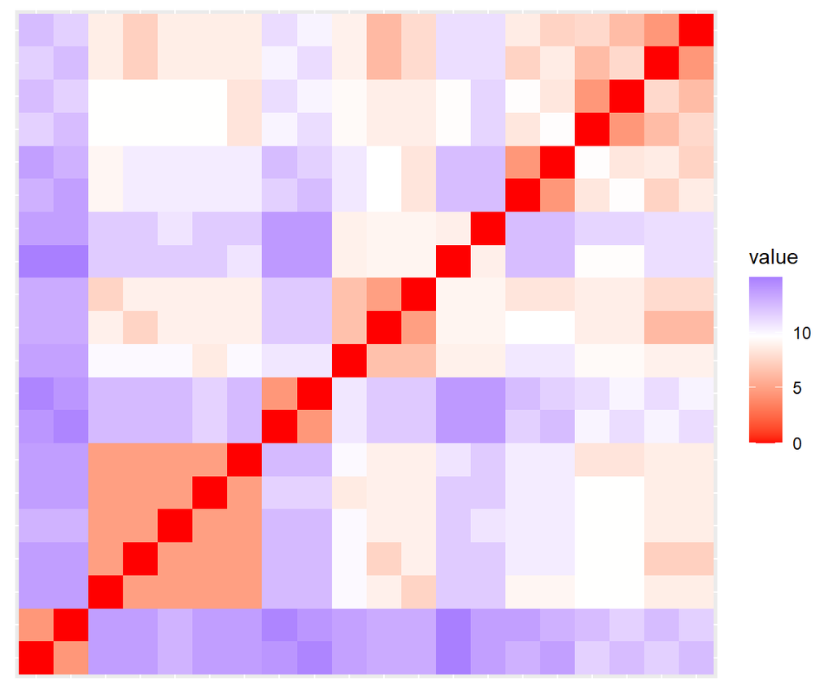

```r
library(cluster)

# scale the similarity matrix
df = scale(df)
df = df[, colSums(is.na(df)) != nrow(df)]

res = get_clust_tendency(df, 10, graph = TRUE)
res$plot
```

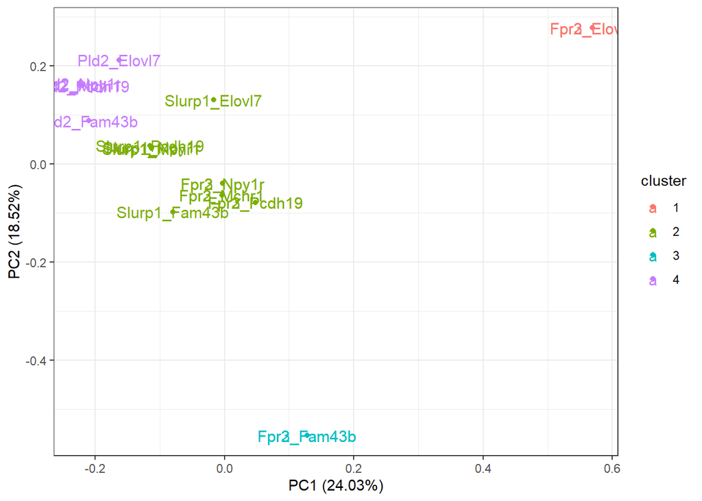

```r
# plot clustering result
library(ggfortify)

km.res = kmeans(df, 4, nstart = 20)
autoplot(km.res, data=df, label=TRUE, label.size=4, frame=FALSE) + theme_bw()
```

# Part VI: Infer functionally related signaling pathways

```r
# infer pathway-related network based on CellChat L-R database
exSigNet.Path <- check_Pathway(Graph = exSigNet,
                          LR.DB = CellChatLR.mouse,
                          Par = 2)

exSigNet.Path
```

```
#> [[1]]
#> [[1]]$Graph.Edge
#>      from     to   source          path from.Role  to.Role     Weight
#> 1  Slurp1 Chrna4 CellChat Slurp1*Chrna4    Ligand Receptor 0.33941215
#> 5  Slurp1 Chrnb2 CellChat Slurp1*Chrnb2    Ligand Receptor 0.38123576
#> 11 Chrna4  Stat3 NicheNet  Chrna4*Stat3  Receptor       TF 0.37259113
#> 13 Chrnb2  Stat3 NicheNet  Chrnb2*Stat3  Receptor       TF 0.41592896
#> 19  Stat3  Mchr1 NicheNet   Stat3*Mchr1        TF   Target 0.12280930
#> 24  Stat3  Npy1r NicheNet   Stat3*Npy1r        TF   Target 0.19820729
#> 29  Stat3 Elovl7 NicheNet  Stat3*Elovl7        TF   Target 0.19631619
#> 32  Stat3 Pcdh19 NicheNet  Stat3*Pcdh19        TF   Target 0.27872292
#> 33  Stat3 Fam43b NicheNet  Stat3*Fam43b        TF   Target 0.08563504
#>
#> [[1]]$Graph.Node
#>      Gene     Role      Size
#> 1  Slurp1   Ligand 1.0000000
#> 5  Chrna4 Receptor 1.0276064
#> 8  Chrnb2 Receptor 1.2322489
#> 14  Stat3       TF 1.1558063
#> 18  Mchr1   Target 0.2422603
#> 19  Npy1r   Target 0.4277623
#> 20 Elovl7   Target 0.4226840
#> 21 Pcdh19   Target 0.6686756
#> 22 Fam43b   Target 0.1620604
#>
#>
#> [[2]]
#> [1] 0.02236483
#>
#> [[3]]
#> [[3]][[1]]
#> [1] "SLURP" "SLURP"
```

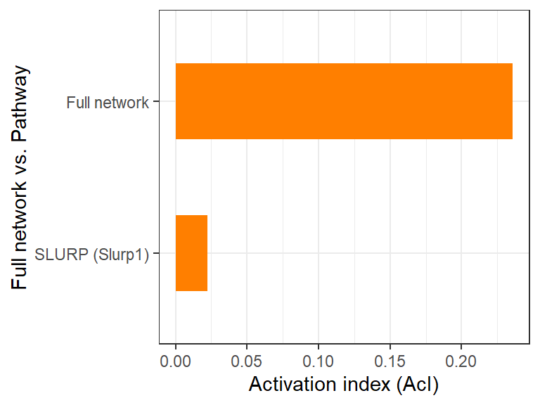

```r
# compare the activation index
AcI_Full <- get_AcI(Graph = exSigNet, Par = 2)
AcI_Path <- exSigNet.Path[[2]]
data.AcI <- data.frame(AcI = c(AcI_Full, AcI_Path), Pathway = c('Full network', 'SLURP (Slurp1)'))

data.AcI %>%
  mutate(Pathway = fct_reorder(Pathway, AcI)) %>%
  ggplot(aes(x=AcI, y=Pathway)) +
    geom_bar(stat="identity", fill="#FF7F00", alpha=1, width=.5) +
    xlab("Activation index (AcI)") +
    ylab("Full network vs. Pathway") +
    theme_bw()
```

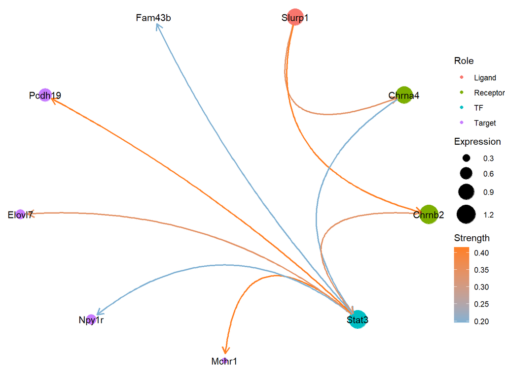

```r
# hierarchy plot
exSigNet.Path_plot <- get_readyforplot(Graph = exSigNet.Path[[1]])

ggraph(exSigNet.Path_plot[[1]], layout = 'dendrogram', circular = TRUE) +
  geom_node_point(aes(filter = leaf, x=x, y=y, colour=Role, size=Expression)) +
  theme_void() +
  geom_conn_bundle(data = get_con(from = exSigNet.Path_plot[[2]]$from,
                                  to = exSigNet.Path_plot[[2]]$to,
                                  Strength = exSigNet.Path_plot[[2]]$weight), width = 0.75, aes(colour=Strength),
                   arrow = arrow(length = unit(3, 'mm')), start_cap = circle(3, 'mm'), end_cap = circle(3, 'mm')) +
  scale_edge_color_continuous(low="#80b1d3", high="#FF7F24")+
  geom_node_text(aes(label = node)) +
  scale_size_continuous( range = c(0.1,10) )
```

```r
exSigNet.Path
```

```
#> [[1]]
#> [[1]]$Graph.Edge
#>      from     to   source          path from.Role  to.Role     Weight
#> 1  Slurp1 Chrna4 CellChat Slurp1*Chrna4    Ligand Receptor 0.33941215
#> 5  Slurp1 Chrnb2 CellChat Slurp1*Chrnb2    Ligand Receptor 0.38123576
#> 11 Chrna4  Stat3 NicheNet  Chrna4*Stat3  Receptor       TF 0.37259113
#> 13 Chrnb2  Stat3 NicheNet  Chrnb2*Stat3  Receptor       TF 0.41592896
#> 19  Stat3  Mchr1 NicheNet   Stat3*Mchr1        TF   Target 0.12280930
#> 24  Stat3  Npy1r NicheNet   Stat3*Npy1r        TF   Target 0.19820729
#> 29  Stat3 Elovl7 NicheNet  Stat3*Elovl7        TF   Target 0.19631619
#> 32  Stat3 Pcdh19 NicheNet  Stat3*Pcdh19        TF   Target 0.27872292
#> 33  Stat3 Fam43b NicheNet  Stat3*Fam43b        TF   Target 0.08563504
#>
#> [[1]]$Graph.Node
#>      Gene     Role      Size
#> 1  Slurp1   Ligand 1.0000000
#> 5  Chrna4 Receptor 1.0276064
#> 8  Chrnb2 Receptor 1.2322489
#> 14  Stat3       TF 1.1558063
#> 18  Mchr1   Target 0.2422603
#> 19  Npy1r   Target 0.4277623
#> 20 Elovl7   Target 0.4226840
#> 21 Pcdh19   Target 0.6686756
#> 22 Fam43b   Target 0.1620604
#>
#>
#> [[2]]
#> [1] 0.02236483
#>
#> [[3]]
#> [[3]][[1]]
#> [1] "SLURP" "SLURP"
```

# Part VII: Evaluate GO analysis results

```r
library(org.Mm.eg.db)
```

```r
# GO analysis and evaluate top 5 GO terms
GO.exSigNet <- get_EnrichAnalysis(Graph = exSigNet,
                               OrgDb = org.Mm.eg.db,
                               Number.of.Terms = 5,
                               ont = "BP",
                               pvalueCutoff = 0.05,
                               qvalueCutoff = 0.2)
GO.exSigNet
```

```
#> $`GO analysis results`
#> #
#> # over-representation test
#> #
#> #...@organism     Mus musculus
#> #...@ontology     BP
#> #...@keytype      ENTREZID
#> #...@gene     chr [1:22] "57277" "14294" "14289" "18806" "11438" "11820" "11840" "11444" ...
#> #...pvalues adjusted by 'BH' with cutoff <0.05
#> #...619 enriched terms found
#> 'data.frame':    619 obs. of  9 variables:
#>  $ ID         : chr  "GO:0007631" "GO:1903305" "GO:1901214" "GO:0006979" ...
#>  $ Description: chr  "feeding behavior" "regulation of regulated secretory pathway" "regulation of neuron death" "response to oxidative stress" ...
#>  $ GeneRatio  : chr  "5/22" "5/22" "6/22" "6/22" ...
#>  $ BgRatio    : chr  "128/29008" "186/29008" "384/29008" "407/29008" ...
#>  $ pvalue     : num  3.83e-08 2.48e-07 3.23e-07 4.54e-07 4.87e-07 ...
#>  $ p.adjust   : num  6.56e-05 1.67e-04 1.67e-04 1.67e-04 1.67e-04 ...
#>  $ qvalue     : num  2.60e-05 6.62e-05 6.62e-05 6.62e-05 6.62e-05 ...
#>  $ geneID     : chr  "11820/11444/20848/207911/18166" "18806/11438/11840/11444/19339" "11820/16653/12387/20848/22187/16476" "18806/11438/11820/22433/12387/16476" ...
#>  $ Count      : int  5 5 6 6 6 6 5 4 5 4 ...
#> #...Citation
#>  T Wu, E Hu, S Xu, M Chen, P Guo, Z Dai, T Feng, L Zhou, W Tang, L Zhan, X Fu, S Liu, X Bo, and G Yu.
#>  clusterProfiler 4.0: A universal enrichment tool for interpreting omics data.
#>  The Innovation. 2021, 2(3):100141
#>
#>
#> $Evaluation
#>             Node.Pct   Exp.Pct                                   GO.Name
#> GO:0007631 0.2727273 0.3408922                          feeding behavior
#> GO:1903305 0.2727273 0.3499993 regulation of regulated secretory pathway
#> GO:1901214 0.2727273 0.3688211                regulation of neuron death
#> GO:0006979 0.2272727 0.2663513              response to oxidative stress
#> GO:1901652 0.2272727 0.1999409                       response to peptide
```

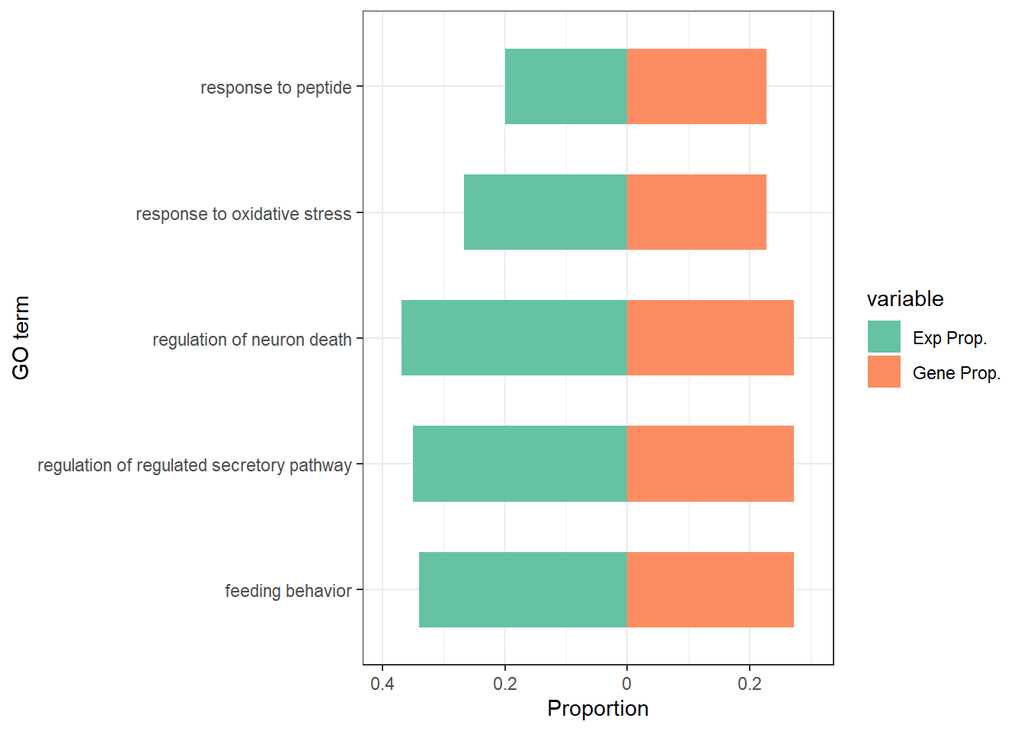

```r
# prepare for bar plot
GO.df <- GO.exSigNet[[2]]

GO.df.1 <- data.frame(GO.term = rownames(GO.df), variable = "Gene Prop.", value = GO.df$Node.Pct, GO.name = GO.df$GO.Name)
GO.df.2 <- data.frame(GO.term = rownames(GO.df), variable = "Exp Prop.", value = GO.df$Exp.Pct, GO.name = GO.df$GO.Name)
GO.df.3 <- rbind(GO.df.1, GO.df.2)

# bar plot
ggplot(GO.df.3, aes(
                x = factor(GO.name, levels = unique(GO.name)),
                y = ifelse(variable == "Gene Prop.", value, -value),  fill = variable)) +
  geom_bar(stat = 'identity', width=0.6)+
  scale_fill_brewer(palette = 'Set2')+
  coord_flip()+
  scale_y_continuous(
    labels = abs,
    expand = expansion(mult = c(0.1, 0.1))) +
    ylab("Proportion") +
    xlab("GO term") +
    theme_bw()
```